# 《R语言》第3章：数据结构

[返回课程主页](https://psychbruce.github.io/RCourse/)

授课教师：包寒吴霜

版权声明：本套课程材料开源，使用和分享必须遵守「创作共用许可协议 CC BY-NC-SA」（来源引用-非商业用途使用-以相同方式共享）。

# Chap03：数据结构

#### 往期要点回顾

- [Chap02 # R对象类型（向量、列表）](https://psychbruce.github.io/RCourse/Chap02#%E7%9F%A5%E8%AF%86%E7%82%B9r%E5%AF%B9%E8%B1%A1%E4%B8%8E%E5%87%BD%E6%95%B0)

#### 本章要点目录

- 【实践1】矩阵操作
- 【实践2】数据变量操作（重点）
- 【知识点】数据框的变量名要求
- 【探索发现】数据框（data.frame）和数据表（data.table）对比
- 【知识点】“一站式”数据导入导出函数
- 【实践3】数据导出练习（重点）
- 【实践4】数据导入练习（重点）
- 【知识点】RData数据压缩存储格式
- 【知识点】Web前端数据结构
- 【实践5】静态网页解析

```r
## 本章所需R包
library(bruceR)
library(rvest)  # 网络爬虫
```

# R对象类型：二维数据表结构

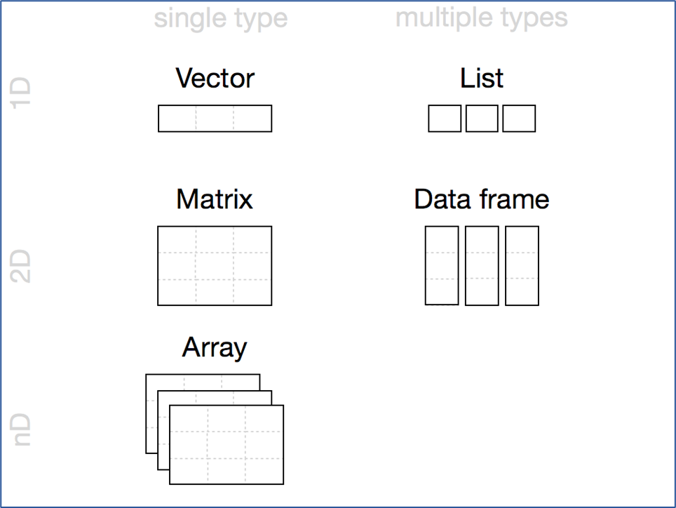

## 矩阵（matrix）

- 二维、单类型数据

#### 【实践1】矩阵操作

```r
x = 1:9
m = matrix(x, nrow=3, ncol=3)
m
```

```
     [,1] [,2] [,3]
[1,]    1    4    7
[2,]    2    5    8
[3,]    3    6    9
```

```r
m[1, ]
```

```
[1] 1 4 7
```

```r
m[, 3]
```

```
[1] 7 8 9
```

```r
m[1, 3]
```

```
[1] 7
```

```r
nrow(m)  # 行数
```

```
[1] 3
```

```r
ncol(m)  # 列数
```

```
[1] 3
```

```r
rowMeans(m)  # 行平均
```

```
[1] 4 5 6
```

```r
colMeans(m)  # 列平均
```

```
[1] 2 5 8
```

```r
t(m)  # 矩阵转置
```

```
     [,1] [,2] [,3]
[1,]    1    2    3
[2,]    4    5    6
[3,]    7    8    9
```

```r
rownames(m)  # 矩阵行名称（默认没有）
```

```r
colnames(m)  # 矩阵列名称（默认没有）
```

```r
rownames(m) = c("a", "b", "c")  # 设置矩阵行名称
colnames(m) = c("A", "B", "C")  # 设置矩阵列名称
m  # 矩阵有名字了！
```

```
  A B C
a 1 4 7
b 2 5 8
c 3 6 9
```

```r
m[1, 3]
```

```
[1] 7
```

```r
m["a", "C"]
```

```
[1] 7
```

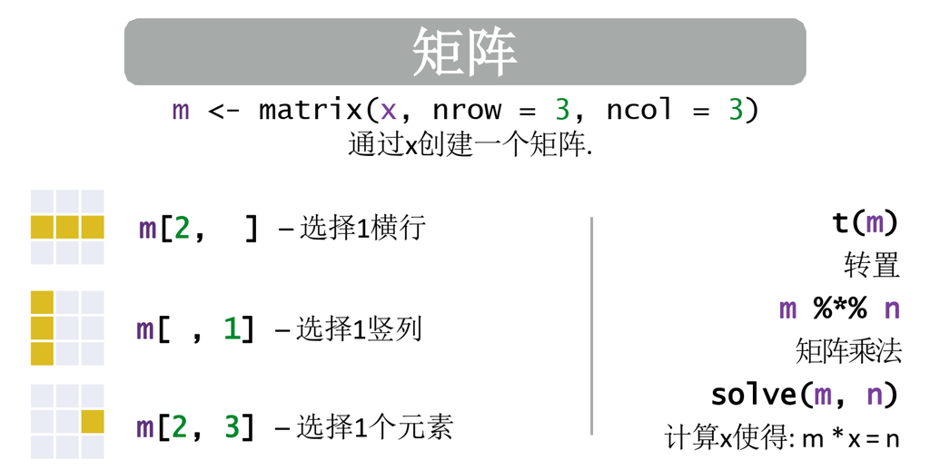

## 数据框（data frame）

- 二维、多类型数据⭐️（最常用的数据类型！）
  - 相当于Excel表格在R里的样子
    - 每一列是一个变量
    - 每一行是一个观测值

#### 【实践2】数据变量操作

```r
## 数据框生成
d = data.frame(x=1:4, y=c("a", "b", "c", "d"))
d
```

```
  x y
1 1 a
2 2 b
3 3 c
4 4 d
```

```r
## 数据框信息
names(d)  # 变量名
```

```
[1] "x" "y"
```

```r
length(d)  # 变量个数
```

```
[1] 2
```

```r
ncol(d)  # 列数（变量个数）
```

```
[1] 2
```

```r
nrow(d)  # 行数（观测个数）
```

```
[1] 4
```

```r
str(d)  # 查看数据结构与变量类型
```

```
'data.frame':   4 obs. of  2 variables:
 $ x: int  1 2 3 4
 $ y: chr  "a" "b" "c" "d"
```

```r
View(d)  # 查看对象
```

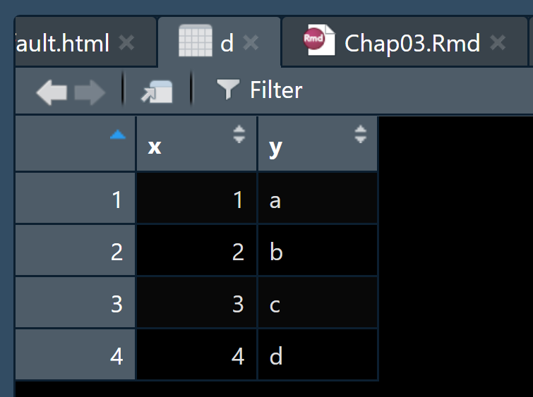

```r
d$x  # 取变量
```

```
[1] 1 2 3 4
```

```r
d$y  # 取变量
```

```
[1] "a" "b" "c" "d"
```

```r
d[["y"]]  # 取变量
```

```
[1] "a" "b" "c" "d"
```

```r
d[1, "y"]  # 取单个值
```

```
[1] "a"
```

```r
## 新变量增加
d$univ = c("ECNU", "BNU", "PKU", "THU")
d$univ = as.factor(d$univ)
str(d)  # 数据结构
```

```
'data.frame':   4 obs. of  3 variables:
 $ x   : int  1 2 3 4
 $ y   : chr  "a" "b" "c" "d"
 $ univ: Factor w/ 4 levels "BNU","ECNU","PKU",..: 2 1 3 4
```

```r
## 数据框提取
d[, 2:3]  # 取子集
```

```
  y univ
1 a ECNU
2 b  BNU
3 c  PKU
4 d  THU
```

```r
d[1:2, 2:3]  # 取子集
```

```
  y univ
1 a ECNU
2 b  BNU
```

```r
d[d$x < 3, ]  # 按条件取子集
```

```
  x y univ
1 1 a ECNU
2 2 b  BNU
```

```r
d[d$x < 3 & d$y %in% c("a", "c"), c("y", "univ")]  # 按条件取子集
```

```
  y univ
1 a ECNU
```

```r
## 数据框组合
d$univ = NULL  # 删除变量
d1 = data.frame(x=5:8, y=c("e", "f", "g", "h"))
d.d1 = rbind(d, d1)  # rbind()行合并
d.d1
```

```
  x y
1 1 a
2 2 b
3 3 c
4 4 d
5 5 e
6 6 f
7 7 g
8 8 h
```

```r
d2 = data.frame(z=5:8)
d.d2 = cbind(d, d2)  # cbind()列合并
d.d2
```

```
  x y z
1 1 a 5
2 2 b 6
3 3 c 7
4 4 d 8
```

```r
## 变量名设置
names(d.d2)
```

```
[1] "x" "y" "z"
```

```r
names(d.d2)[2]
```

```
[1] "y"
```

```r
names(d.d2)[1:2] = c("xxx", "yyy")  # 修改变量名
d.d2  # 变量名已修改
```

```
  xxx yyy z
1   1   a 5
2   2   b 6
3   3   c 7
4   4   d 8
```

```r
names(d.d2) = c("var.1", "var.2", "var.3")  # 变量名可以包含.
d.d2  # 变量名已修改
```

```
  var.1 var.2 var.3
1     1     a     5
2     2     b     6
3     3     c     7
4     4     d     8
```

#### 【知识点】数据框的变量名要求

- 建议使用英文（区分大小写）、数字、点（`.`）、下划线（`_`）命名变量
  - 一般以英文开头，如`Item1`、`Item.1`、`Item_1`
- 变量名不建议出现中文、横线、空格

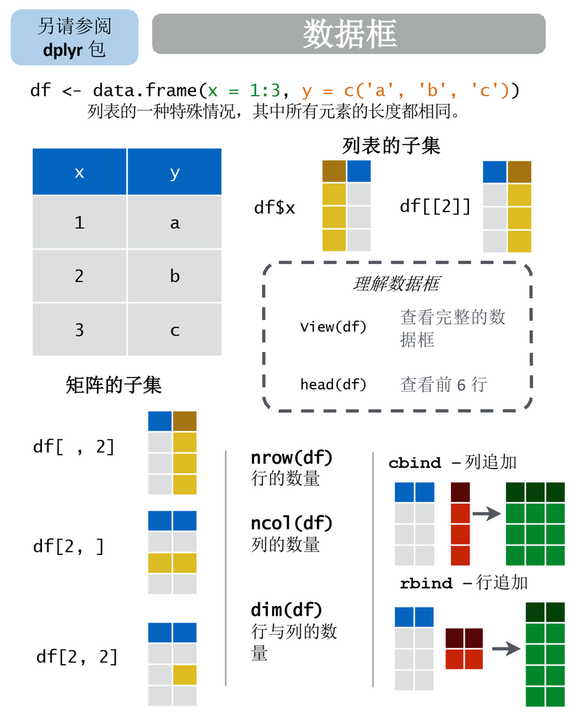

#### 【探索发现】数据框（data.frame）和数据表（data.table）对比

- [第6章](https://psychbruce.github.io/RCourse/Chap06)将会系统学习一种**先进、高效、简约**的数据表类型（data.table）

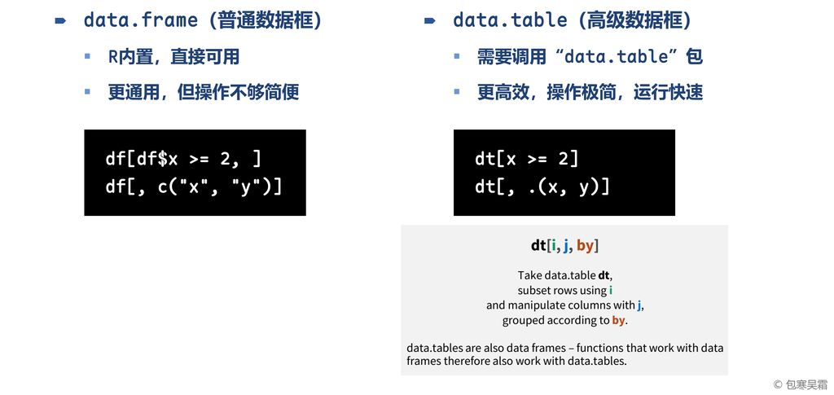

# 外部数据导入导出

#### 【知识点】“一站式”数据导入导出函数

- `bruceR`包的`import()`和`export()`函数提供了“一站式”数据导入导出功能
  - 根据文件后缀名，全自动选择最优导入导出方式，不再需要记住大量的`read_xxx()`函数，节省时间，提升效率！
    - 细节可查阅帮助文档
- `import()`帮助文档
  - https://psychbruce.github.io/bruceR/reference/import.html

[figure not shown]

- `export()`帮助文档
  - https://psychbruce.github.io/bruceR/reference/export.html

[figure not shown]

## “一站式”数据导出

#### 【实践3】数据导出练习

```r
library(bruceR)
between.2  # 将要导出的示例数据
```

```
   A B SCORE
1  1 1     3
2  1 1     6
3  1 1     4
4  1 1     3
5  1 2     4
6  1 2     6
7  1 2     4
8  1 2     2
9  1 3     5
10 1 3     7
11 1 3     5
12 1 3     2
13 2 1     4
14 2 1     5
15 2 1     3
16 2 1     3
17 2 2     8
18 2 2     9
19 2 2     8
20 2 2     7
21 2 3    12
22 2 3    13
23 2 3    12
24 2 3    11
```

```r
## 导出到剪切板，可粘贴（Ctrl + V）到其他地方
export(between.2)
```

```r
## 导出到CSV逗号分隔值纯文本文件
export(between.2, file="data.csv")
## 导出到SPSS数据文件
export(between.2, file="data.sav")

## 导出到Excel文件（Sheet1、Sheet2、Sheet3）
export(list(between.1, between.2, between.3), file="data.xlsx")

## 导出到Excel文件（Sheet名称：d1、d2、d3）
export(
  list(between.1, between.2, between.3),
  sheet = c("d1", "d2", "d3"),  # 设定每个数据导出的Sheet名称
  file = "data_named.xlsx"
)
```

## “一站式”数据导入

#### 【实践4】数据导入练习

```r
library(bruceR)

d1 = import("data_named.xlsx", sheet="d1")
d2 = import("data_named.xlsx", sheet="d2")
d3 = import("data_named.xlsx", sheet="d3")

df = import("data.csv")
dt = import("data.csv", as="data.table")  # 导入为data.table对象

class(df)  # data.frame
```

```
[1] "data.frame"
```

```r
class(dt)  # data.table（基于data.frame的高级数据表对象）
```

```
[1] "data.table" "data.frame"
```

```r
str(dt)  # 数据结构
```

```
Classes 'data.table' and 'data.frame':  24 obs. of  3 variables:
 $ A    : int  1 1 1 1 1 1 1 1 1 1 ...
 $ B    : int  1 1 1 1 2 2 2 2 3 3 ...
 $ SCORE: int  3 6 4 3 4 6 4 2 5 7 ...
 - attr(*, ".internal.selfref")=<pointer: 0x000001ac0bf90c50>
```

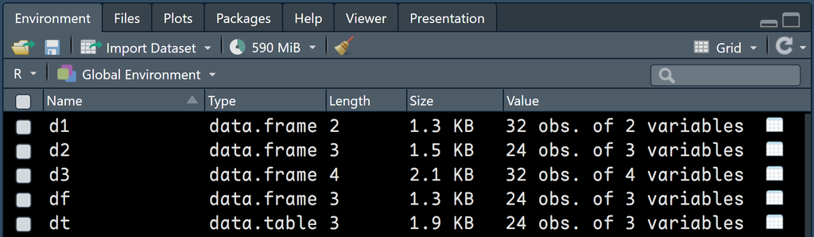

## * 拓展：数据压缩存储格式

#### 【知识点】RData数据压缩存储格式

- .RData（也可写为.rdata、.rda）：特殊文件格式，可压缩存储多个R对象、数据集
  - `"gzip"`：快速压缩（最快，默认）
  - `"bzip2"`：中度压缩（较快）
  - `"xz"`：极限压缩（较慢）

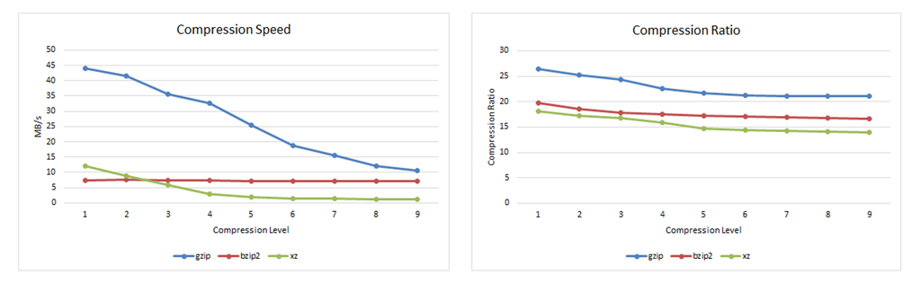

```r
## 保存为RData
save(d1, d2, d3, file="datasets1.RData")

save(d1, d2, d3,
     file = "datasets2.RData",
     compress = "xz",        # "gzip", "bzip2", "xz"
     compression_level = 9)  # 压缩程度：1~9

## 移除环境中的数据对象
rm(d1, d2, d3)

## 载入RData中压缩存储的数据对象
load("datasets1.RData")
str(d1)  # 已载入到环境
```

```
'data.frame':   32 obs. of  2 variables:
 $ A    : num  1 1 1 1 1 1 1 1 2 2 ...
 $ SCORE: num  3 6 4 3 5 7 5 2 4 6 ...
```

```r
str(d2)  # 已载入到环境
```

```
'data.frame':   24 obs. of  3 variables:
 $ A    : num  1 1 1 1 1 1 1 1 1 1 ...
 $ B    : num  1 1 1 1 2 2 2 2 3 3 ...
 $ SCORE: num  3 6 4 3 4 6 4 2 5 7 ...
```

```r
str(d3)  # 已载入到环境
```

```
'data.frame':   32 obs. of  4 variables:
 $ A    : num  1 1 1 1 1 1 1 1 1 1 ...
 $ B    : num  1 1 1 1 1 1 1 1 2 2 ...
 $ C    : num  1 1 1 1 2 2 2 2 1 1 ...
 $ SCORE: num  3 6 4 3 5 7 5 2 4 6 ...
```

```r
## 导入在线数据（douban_movies.RData）
data = import("https://psychbruce.github.io/RCourse/data/douban_movies.RData")
# View(data)
```

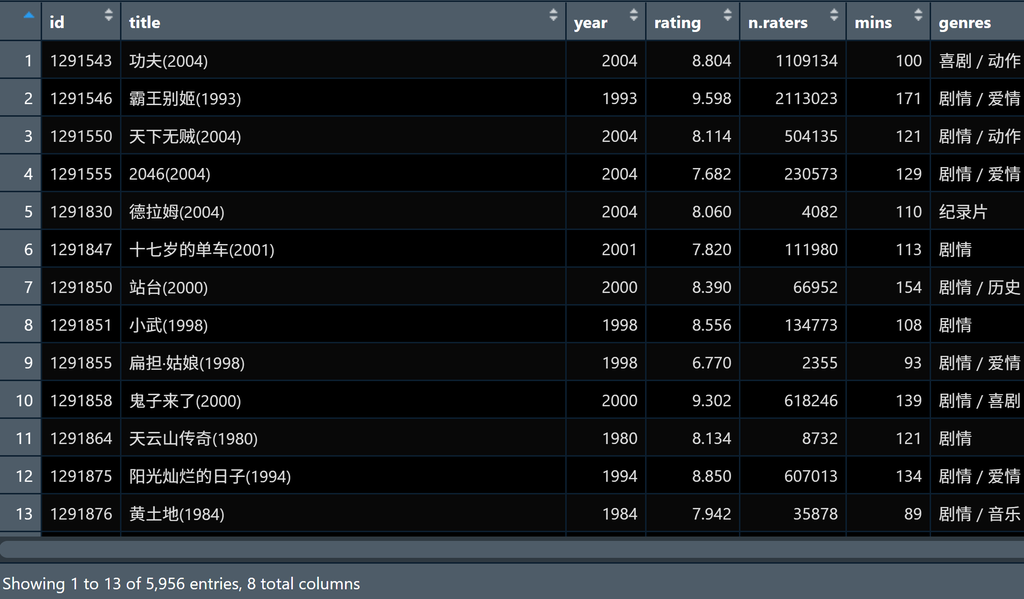

## * 拓展：网络爬虫自动数据采集

#### 【知识点】Web前端数据结构

- 网页组成三大元素
  - HTML（结构）：超文本标记语言
  - CSS（样式）：层叠样式表
  - JavaScript（动作）：网页动作脚本

[figure not shown]

[figure not shown]

[figure not shown]

#### 【实践5】静态网页解析

- 静态网页示例：华东师范大学心理与认知科学学院“师资队伍”页面
  - 点击查看网页内容：https://psy.ecnu.edu.cn/17437/list.htm
- 网页元素提取：CSS选择代码
  - CSS选择代码定义了用于精准定位HTML元素的基本模式，可简洁描述想要提取的元素
  - **SelectorGadget****（将这个超链接拖拽到你的浏览器书签栏，即可使用）**
    - [使用教程](https://selectorgadget.com/)

```r
library(rvest)

url = "https://psy.ecnu.edu.cn/17437/list.htm"  # 网页链接
xml = url %>% read_html()  # 读取网页所有信息

xml %>% html_elements(".column-item-link .column-name") %>% html_text2()
```

```
 [1] "各级人才工程"               "认知与神经科学系"
 [3] "毕生发展与学习科学系"       "社会与管理心理学系"
 [5] "健康与临床心理学系"         "人工智能与人因工程系（筹）"
 [7] "实验员/专任助理研究员"      "党政管理"
 [9] "兼职教师"                   "全职博士后"
[11] "荣休教师"                   "永远怀念教师名录"
```

```r
xml %>% html_elements(".subcolumn-name") %>% html_text2()
```

```
 [1] "华东师范大学特聘教授"     "国家级人才项目"
 [3] "国家级青年人才项目"       "中国科协托举人才"
 [5] "教育部新世纪人才"         "上海市曙光学者"
 [7] "上海市浦江学者"           "上海市青年科技启明星项目"
 [9] "上海市晨光计划"           "上海市扬帆计划"
```

```r
xml %>% html_elements(".column-news-title") %>% html_text2()
```

```
 [1] "周晓林 博士"   "蒯曙光 博士"   "周晓林 博士"   "蔡清 博士"
 [5] "郝宁 博士"     "蒯曙光 博士"   "高晓雪 博士"   "罗艺 博士"
 [9] "崔丽娟 博士"   "刘永芳 博士"   "庞维国 博士"   "郝宁 博士"
[13] "刘俊升 博士"   "陆静怡 博士"   "蔡清 博士"     "包寒吴霜 博士"
[17] "李先春 博士"   "刘俊升 博士"   "孟慧 博士"     "庞维国 博士"
[21] "宋永宁博士"    "王弘毅 博士"   "王青 博士"     "席居哲 博士"
[25] "谢鑫宇博士"    "周宁宁 博士"   "张琪 博士"     "包寒吴霜 博士"
[29] "梁一鸣 博士"   "陆静怡 博士"   "王青 博士"     "杨莹 博士"
[33] "周晗昱 博士"   "陈 曦 博士"    "梁一鸣 博士"   "李世佳 博士"
[37] "杨莹 博士"     "周晗昱 博士"
```

# 【作业4】期末自选公开数据导入

作业要求：

- 开始准备个人期末大作业，自主选择任意一个感兴趣的公开数据，写出数据导入代码
  - 数据选择：可以从本课程提供的“[公开数据可选列表](https://docs.qq.com/sheet/DTXNCUWtzWWNuU05Y)”中，选择一篇感兴趣的研究，下载其公开数据中的一个数据文件（只选择一个有代表性的数据文件即可，无需使用研究中的全部数据文件）
  - 数据导入：参考【实践4】代码，使用`bruceR`包的`import()`函数，将该数据导入为`data.table`对象

平台提交：

- 自选论文的DOI链接和公开数据链接
- 原数据打开后的前几行、前几列截图
- 数据导入代码（使用`import()`函数）及导入后的数据结构（使用`str()`函数）截图

[返回课程主页](https://psychbruce.github.io/RCourse/)

© 包寒吴霜